[OHI Science](http://ohi-science.org) | [Citation policy](http://ohi-science.org/citation-policy/)

# OHI 2025 Results

### Overview of goals and subgoals

##### Table A. Description of 10 goals used to calculate OHI scores.

In several tables and figures we refer to the goals and subgoals by their abbreviation. Goals and subgoals have a 2 and 3 character abbreviation, respectively.

| Goal | Abbreviation | Description |
| --- | --- | --- |
| Food Provision | FP | The sustainable harvest of seafood from wild-caught fisheries and mariculture |
| Artisanal Fishing Opportunity | AO | The opportunity for small-scale fishers to supply catch for their families, members of their local communities, or sell in local markets |
| Natural Products | NP | The natural resources that are sustainably extracted from living marine resources |
| Carbon Storage | CS | The condition of coastal habitats that store and sequester atmospheric carbon |
| Coastal Livelihoods and Economies | LE | Coastal and ocean-dependent livelihoods (job quantity and quality) and economies (revenues) produced by marine sectors |
| Tourism and Recreation | TR | The value people have for experiencing and enjoying coastal areas through activities such as sailing, recreational fishing, beach-going, and bird watching |
| Sense of Place | SP | The conservation status of iconic species (e.g., salmon, whales) and geographic locations that contribute to cultural identity |
| Clean Waters | CW | The degree to which ocean regions are free of contaminants such as chemicals, eutrophication, harmful algal blooms, disease pathogens, and trash |
| Biodiversity | BD | The conservation status of native marine species and key habitats that serve as a proxy for the suite of species that depend upon them |
| Coastal Protection | CP | The amount of protection provided by marine and coastal habitats serving as natural buffers against incoming waves |

##### Table B. Description of subgoals used to calculate OHI scores.

The following goals are comprised of 2 subgoals:biodiversity, food provision, sense of place, livelihoods and economies goals.

| Subgoal | Goal | Abbreviation | Description |
| --- | --- | --- | --- |
| Fisheries | Food provision | FIS | The sustainable harvest of seafood from wild-caught fisheries |
| Mariculture | Food provision | MAR | The sustainable harvest of seafood from mariculture practices |
| Habitat | Biodiversity | HAB | The status of key habitats that serve as a proxy for the suite of species that depend upon them |
| Species condition | Biodiversity | SPP | The conservation status of native marine species |
| Iconic species | Sense of place | ICO | The conservation status of iconic species (e.g., salmon, whales) that contribute to cultural identity |
| Lasting special places | Sense of place | LSP | The conservation status of geographic locations that contribute to cultural identity |
| Livelihoods | Coastal livelihoods and economies | LIV | Coastal and ocean-dependent livelihoods (job quantity and quality) produced by marine sectors |
| Economies | Coastal livelihoods and economies | ECO | Coastal and ocean-dependent economies (revenues) produced by marine sectors |

### Datasets and additional information

See the [Methods](https://raw.githack.com/OHI-Science/ohi-global/draft/documents/methods/Supplement.html) document for more information about the models and data used to calculate the global Ocean Health Index.

A CSV formatted dataset from the 2025 assessment is [available](https://raw.githubusercontent.com/OHI-Science/ohi-global/draft/yearly_results/global2025/OHI_final_formatted_scores_2025-09-11.csv), right click on data and select “Save as…”. These data include index and goal/subgoal scores (as well as the dimensions used to calculate scores: status, trend, pressure, resilience) for all 14 assessment years (2012-2025). See [README](https://github.com/OHI-Science/ohi-global/tree/draft/yearly_results/global2025) for description of data.

The data layers (described in section 7 in Methods) and functions used to calculate scores can be downloaded from Github: [ohi-global v2024.1: Global scenarios data for Ocean Health Index](https://github.com/OHI-Science/ohi-global/releases).

The files used to prepare data layers for the ohi-global assessment can be downloaded from Github: [ohiprep v2024.1: Preparation of data for 2024 Ocean Health Index global assessment](https://github.com/OHI-Science/ohiprep_v2024/releases).

The core functions used to calculate OHI scores can be downloaded as a package from Github, using the following code in [R](https://cran.r-project.org/):

```r
install.packages('devtools')
library(devtools)

install_github('ohi-science/ohicore')
library(ohicore)
```

### Summary of score results

##### Figure A. Regional 2025 OHI index scores.

Map (top) and histogram (bottom) of 2025 index scores for each OHI region.

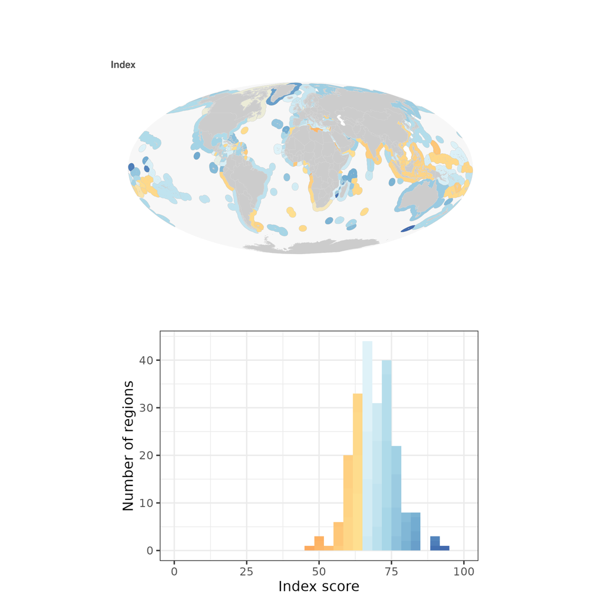

##### Figure B. Flowerplot of 2025 goal/subgoal scores

Flower plot describing the 2025 average global index (middle) and goal (petals) scores. Scores are an eez area weighted average of regional scores.

Flower plots for each region can be downloaded from [here](https://github.com/OHI-Science/ohi-global/tree/draft/yearly_results/global2025/Results/figures/FlowerPlots)

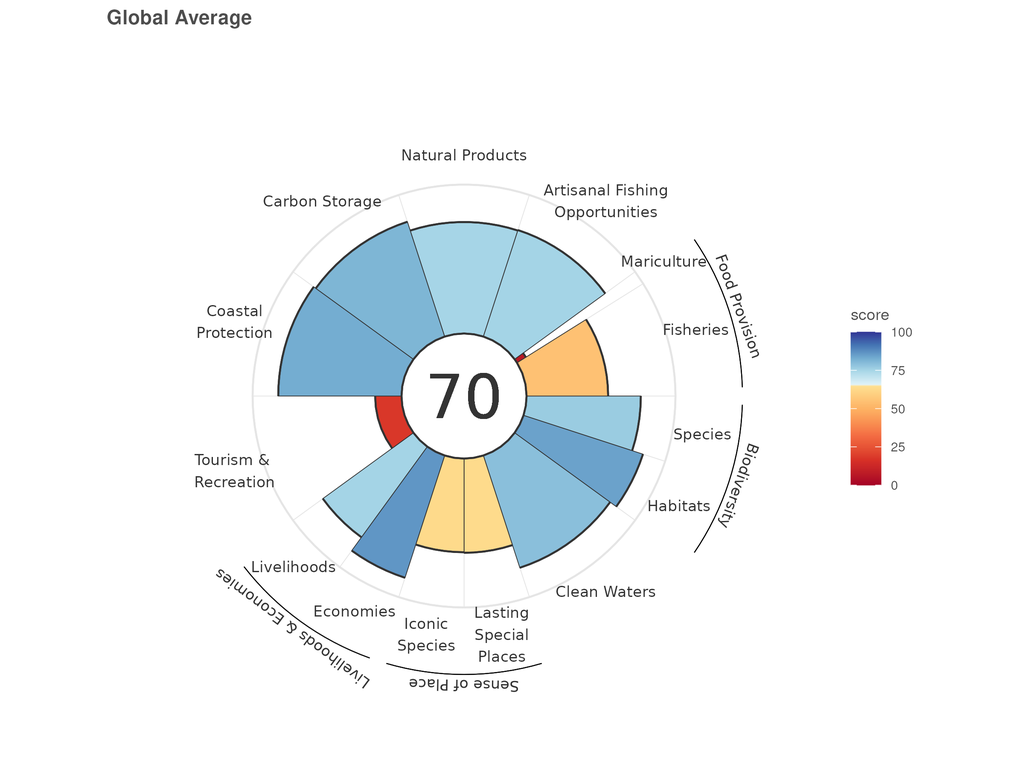

##### Figure C. Maps and histograms of 2025 OHI goal scores.

The 2025 scores for each of the 10 OHI goals displayed for each region (left) and as a histogram (right).

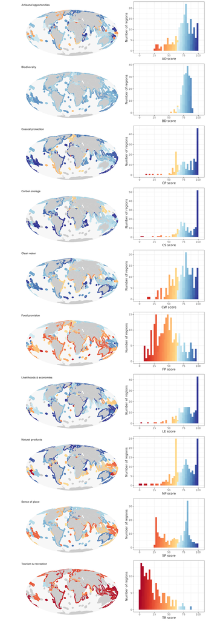

##### Figure D. Maps and histograms of 2025 OHI subgoal scores.

The subgoal 2025 scores for the following goals: biodiversity, foob provision, sense of place, and livelihoods and economies. The scores are displayed as a map (left) and histogram (right).

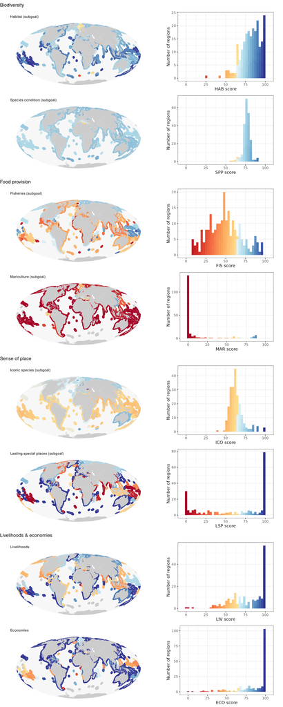

##### Figure E. Country scores across scenario year

Overview of the scores from the 2025 assessment. Each row represents a region, the main groupings represent goals, and within each goal there are 14 years of data. Black regions indicate no data. Download the [png version](https://github.com/OHI-Science/ohi-global/raw/draft/yearly_results/global2025/Results/figures/carpetPlot.png) to zoom in to see specific regions.

This plot is good for providing a quick overview of:

- What is the range of scores?
- Which goals tend to have high scores across most regions (species, habitat)
- Which goals have a lot of variation across regions (tourism & recreation, lasting special places)
- Which goals are volatile across years (natural products, tourism & recreation)

[figure not shown]

### Summary of average annual change in scores

##### Table C. Global average scores for index and goals.

Global scores (eez area weighted average of all regions) for index and goal/subgoals for all years.

| goal | 2012 | 2013 | 2014 | 2015 | 2016 | 2017 | 2018 | 2019 | 2020 | 2021 | 2022 | 2023 | 2024 | 2025 |
| --- | --- | --- | --- | --- | --- | --- | --- | --- | --- | --- | --- | --- | --- | --- |
| Index | 71.97 | 72.65 | 73.09 | 73.70 | 74.26 | 74.33 | 74.40 | 74.89 | 74.68 | 74.60 | 74.96 | 70.11 | 69.70 | 69.75 |
| Artisanal opportunities | 74.96 | 75.28 | 75.23 | 74.99 | 74.48 | 74.10 | 74.16 | 73.88 | 76.17 | 75.79 | 78.50 | 78.94 | 75.79 | 75.17 |
| Species condition (subgoal) | 79.23 | 79.23 | 79.03 | 78.82 | 78.61 | 78.41 | 78.20 | 77.99 | 77.78 | 77.57 | 77.36 | 77.15 | 76.95 | 76.73 |
| Biodiversity | 80.38 | 80.28 | 80.45 | 81.18 | 81.32 | 81.25 | 81.14 | 81.02 | 80.76 | 80.71 | 80.66 | 80.65 | 80.48 | 79.71 |
| Habitat (subgoal) | 81.60 | 81.38 | 81.93 | 83.61 | 84.11 | 84.19 | 84.19 | 84.15 | 83.83 | 83.94 | 84.06 | 84.26 | 84.12 | 82.69 |
| Coastal protection | 79.45 | 79.45 | 79.45 | 79.45 | 79.32 | 78.93 | 78.80 | 78.63 | 78.67 | 78.85 | 79.34 | 79.80 | 80.01 | 78.26 |
| Carbon storage | 81.05 | 81.04 | 81.05 | 81.05 | 81.04 | 81.03 | 81.08 | 81.11 | 81.10 | 81.10 | 81.10 | 81.09 | 81.09 | 81.08 |
| Clean water | 74.84 | 74.63 | 75.22 | 75.38 | 75.37 | 75.61 | 75.92 | 76.58 | 76.79 | 77.03 | 76.98 | 77.39 | 77.44 | 79.26 |
| Fisheries (subgoal) | 54.56 | 54.92 | 54.87 | 54.63 | 54.22 | 53.95 | 53.53 | 53.91 | 54.16 | 54.55 | 55.07 | 54.99 | 54.89 | 54.77 |
| Food provision | 50.74 | 51.17 | 51.02 | 50.67 | 50.27 | 50.04 | 49.35 | 49.65 | 49.42 | 49.63 | 50.14 | 50.19 | 50.16 | 50.03 |
| Mariculture (subgoal) | 5.80 | 5.71 | 5.72 | 5.76 | 5.87 | 5.98 | 6.13 | 6.23 | 6.35 | 6.49 | 6.70 | 6.92 | 7.01 | 7.04 |
| Iconic species (subgoal) | 66.56 | 66.60 | 68.20 | 68.37 | 69.03 | 68.43 | 68.46 | 68.85 | 66.58 | 64.62 | 64.27 | 64.16 | 64.04 | 64.07 |
| Sense of place | 61.23 | 61.28 | 62.73 | 63.29 | 64.20 | 64.74 | 65.22 | 65.79 | 64.88 | 63.89 | 63.86 | 63.76 | 63.69 | 63.68 |
| Lasting special places (subgoal) | 55.91 | 55.96 | 57.25 | 58.21 | 59.38 | 61.04 | 61.97 | 62.73 | 63.19 | 63.16 | 63.44 | 63.36 | 63.35 | 63.28 |
| Natural products | 72.16 | 72.16 | 72.16 | 73.27 | 76.48 | 75.74 | 74.75 | 76.29 | 72.80 | 72.31 | 72.90 | 74.79 | 77.00 | 78.19 |
| Tourism & recreation | 69.60 | 72.84 | 75.71 | 81.18 | 84.30 | 86.93 | 89.24 | 92.03 | 92.74 | 93.29 | 92.86 | 21.41 | 17.39 | 17.72 |

##### Figure F. Average annual change in OHI Index scores.

Map (top) and histogram (bottom) of the slope estimates from a linear regression model of the Index scores from 2012 to 2025 for each region.

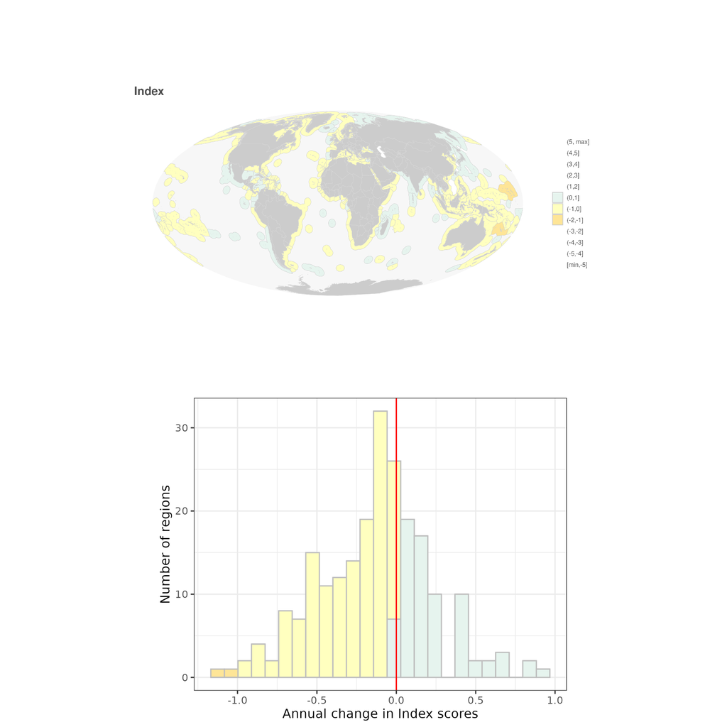

##### Figure G. Average annual change in OHI goal scores.

Map of the slope estimates from a linear regression model of the 10 goal scores from 2012 to 2025 for each region.

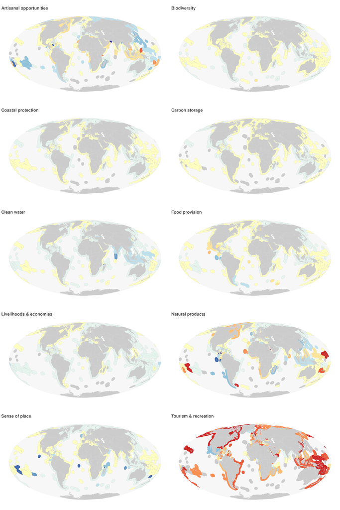

##### Figure H. Average annual change in OHI subgoal scores.

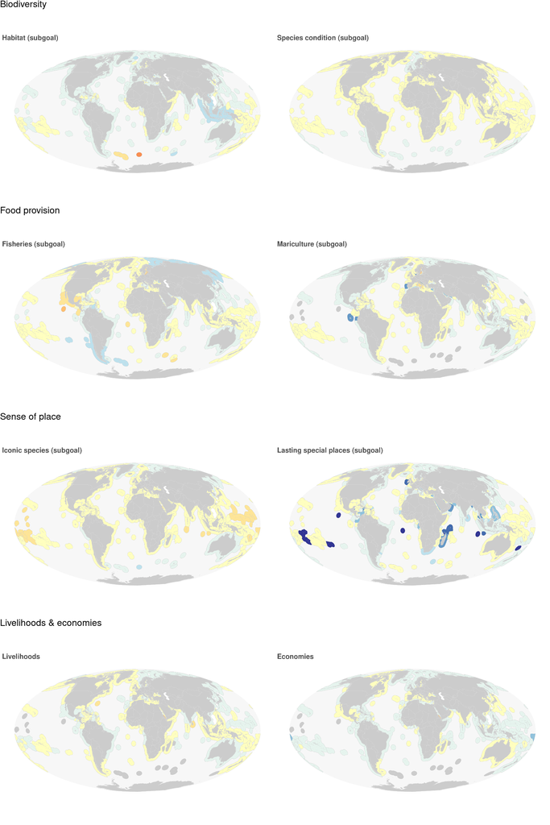

##### Figure I. Barplot of average annual change in goal trends for each region.

The values are the slope estimate from a linear regression model of the scores from 2012 to 2025 for each region and goal.

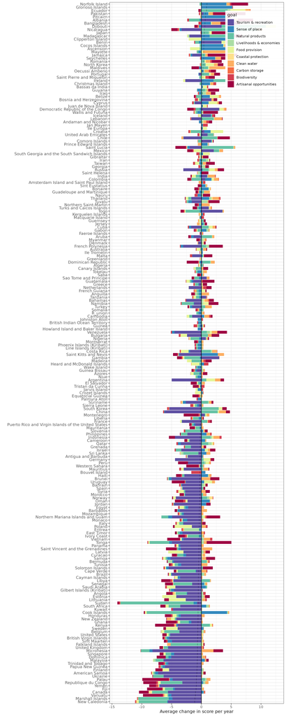

##### Figure J. Comparing trend and average index scores

To obtain a more complete picture of which regions are doing well and which are doing poorly we compared the average index scores (averaged over 2012 to 2025) and the trends for each region.

Of most concern are regions that have poor scores and declining trends.

The following is an interactive plot (region names are visible when hovering over the points) showing the relationship between average index scores and trend. The horizontal line represents the 0 trend and the vertical line is the average of the average index scores.

[interactive chart not shown]